# CWRU DSCI351-351m-451: Lab Exercise LE1

- is survival independent of whether or not the patient got a transplant?
- Explain your reasoning.

- suggest about the efficacy (effectiveness) of the heart transplant treatment.

### LE1-7c) What proportion

- of patients in the treatment group and what proportion of patients in the control group
- died?

```r
controlDeathProportion <- 30/34 * 100
controlDeathProportion
```

```
[1] 88.23529
```

```r
treatmentDeathProportion <- 45/69 * 100
treatmentDeathProportion
```

```
[1] 65.21739
```

ANSWER -> 88.24% of the control group patients died and 65.22% of the treatment group patients died

### LE1-7d) One approach for investigating whether or not the treatment is effective

- is to use a randomization technique.

#### LE1-7d-i. What are the claims being tested?

ANSWER -> Does the heart transplant treatment increase a patient’s lifespan/survival time?

#### LE1-7d-ii. The paragraph below describes the set up for such approach, if we were to do it without using statistical software.

```r
totalAmount <- 69 + 34
totalDead <- 30 + 45
totalAlive <- totalAmount - totalDead
totalDead
```

```
[1] 75
```

```r
totalAlive
```

```
[1] 28
```

```r
treatmentDeathProportion - controlDeathProportion
```

```
[1] -23.0179
```

- Fill in the blanks with a number or phrase, whichever is appropriate.

We write alive on 28 cards representing patients who were alive at the end of the study, and dead on 75 cards representing patients who were not.

Then, we shuffle these cards and split them into two groups:

- one group of size 69 representing treatment,
- and another group of size 34 representing control.

We calculate the difference between the proportion of dead cards in the treatment and control groups (treatment - control) and record this value.

We repeat this 100 times to build a distribution centered a ~ 0.

Lastly, we calculate the fraction of simulations where the simulated differences in proportions are -23.02%.

If this fraction is low,

- we conclude that it is unlikely to have observed such an outcome by chance
  - and that the null hypothesis should be rejected
  - in favor of the alternative hypothesis.

#### LE1-7d-iii. What do the simulation results shown below suggest

- about the effectiveness of the transplant program?

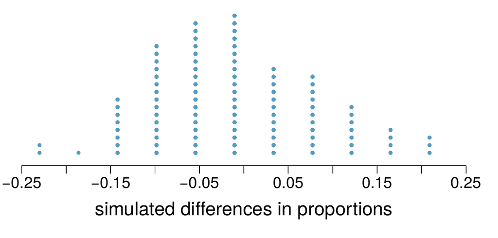

simulation results

ANSWER -> With a difference of -23.02% (~ -0.23), and with reference to the graph the represents the results of the 100 times that the simulated difference of proportion, it seems that 2/100 times a -0.23 difference would be the case(2%). Since this fraction is low, it is unlikely that this outcome has been observed by chance, meaning that we reject the null hypothesis in favor of the alternative hypothesis.

#### Links

1. B. Turnbull et al. “Survivorship of Heart Transplant Data”. In: Journal of the American Statistical Association 69 (1974), pp. 74–80. https://www.jstor.org/stable/pdf/2285502.pdf
2. http://www.r-project.org
3. http://rmarkdown.rstudio.com/
4. [Open Intro Statistics version 4](https://www.openintro.org/book/os/)